# Project 3 - Classification

Welcome to the final project of City Planning/Information 298! You will build two classifiers, looking at movie genres and code violations. This project will give you extra experience classifying data in addition to the song classification labs. We recommend completing 8.3X Labs 4 and 5 before you work on this. By the end of the project, you should know how to:

1. Build a k-nearest-neighbors classifier.
2. Test a classifier on data.

**Please answer all questions, including the free response portions.**

### Logistics

**Deadline.** This project is due at 11:59pm on Friday, 12/20. Due to final grade deadlines, we cannot grant extensions for this project. It's **much** better to be early than late, so start working now.

**Team.** You can work on this project with 3-4 other people (4-5 members in each team total). Please write their information below, and list their information when you submit the project on bCourses. We highly recommend working on this project in person.

**Support.** If you need help on the project, please come to office hours, post on Piazza, and/or talk to your classmates. If you need a guide, please reference the textbook here: https://www.inferentialthinking.com/chapters/17/Classification.html

**Advice.** Develop your answers incrementally. To perform a complicated table manipulation, break it up into steps, perform each step on a different line, give a new name to each result, and check that each intermediate result is what you expect. You can add any additional names or functions you want to the provided cells. Also, please be sure to not re-assign variables throughout the notebook! For example, if you use max_temperature in your answer to one question, do not reassign it later on.

To get started, load `datascience`, `numpy`, `plots`, and `ok`.

```python
# Run this cell to set up the notebook, but please don't change it.

import numpy as np
import math
from datascience import *

# These lines set up the plotting functionality and formatting.
import matplotlib
matplotlib.use('Agg', warn=False)
%matplotlib inline
import matplotlib.pyplot as plots
plots.style.use('fivethirtyeight')
import warnings
warnings.simplefilter(action="ignore", category=FutureWarning)
```

# Team Members

**Please list the names of your team below.**

1. Inthisar Kamal
2. Randy Clopton
3. Kristine Arboleda

# Part 1. The Movies Dataset

In this section of the project, we are exploring movie screenplays. We'll be trying to predict each movie's genre from the text of its screenplay. In particular, we have compiled a list of 5,000 words that might occur in the dialog of a movie. For each movie, our dataset tells us the frequency with which each of these words occurs in its screenplay. All words have been converted to lowercase.

Run the cell below to read the `movies` table. **It may take up to a minute to load.**

```python
movies = Table.read_table('movies.csv')
movies.where("Title", "the matrix").select(0, 1, 2, 3, 4, 5, 10, 30, 5005)
```

| Title | Genre | Year | Rating | # Votes | # Words | it | not | fling |
| --- | --- | --- | --- | --- | --- | --- | --- | --- |
| the matrix | action | 1999 | 8.7 | 389480 | 3792 | 0.030327 | 0.00870253 | 0 |

The above cell prints a few columns of the row for the action movie *The Matrix*. The movie contains 3792 words. The word "it" appears 115 times, as it makes up $\frac{115}{3792} \approx 0.030327$ of the words in the movie. The word "not" appears 33 times, as it makes up $\frac{33}{3792} \approx 0.00870253$ of the words. The word "fling" doesn't appear at all.

All movie titles are unique. The `row_for_title` function provides fast access to the one row for each title.

```python
title_index = movies.index_by('Title')
def row_for_title(title):
    """Return the row for a title, similar to the following expression (but faster)

    movies.where('Title', title).row(0)
    """
    return title_index.get(title)[0]
```

In the following cell, use the `row_for_title` function to find the proportion of times "hey" was stated in the movie, The Terminator.

```python
row_for_title('the terminator').item('hey')
```

```
0.000540833
```

This dataset was extracted from [a Kaggle dataset from Cornell University](https://www.kaggle.com/Cornell-University/movie-dialog-corpus). After transforming the dataset (e.g., converting the words to lowercase, removing the naughty words, and converting the counts to frequencies), we created this new dataset containing the frequency of 5000 common words in each movie.

```python
print('Words with frequencies:', movies.drop(np.arange(6)).num_columns)
print('Movies with genres:', movies.num_rows)
```

```
Words with frequencies: 5000
Movies with genres: 242
```

# Creating the K-Nearest Neighbors Classifier

K-Nearest Neighbors (k-NN) is a classification algorithm. Given some *attributes* (also called *features*) of an unseen example, it decides whether that example belongs to one or the other of two categories based on its similarity to previously seen examples. Predicting the category of an example is called *labeling*, and the predicted category is also called a *label*. An attribute (feature) we have about each movie is *the proportion of times a particular word appears in the movies*, and the labels are two movie genres: romance and action.

## Step 1) Splitting the dataset

We're going to use our `movies` dataset for two purposes.

1. First, we want to *train* movie genre classifiers.
2. Second, we want to *test* the performance of our classifiers.

Hence, we need two different datasets: *training* and *test*.

The purpose of a classifier is to classify unseen data that is similar to the training data. Therefore, we must ensure that there are no movies that appear in both sets. We do so by splitting the dataset randomly. The dataset has already been permuted randomly, so it's easy to split. We just take the top for training and the rest for test.

Run the code below to separate the datasets into two tables.

```python
### Split the dataset into two separate sets.
## Choose the best proportion to generate your training set; the following code will split movies into 2 sets.
# The test_proportion will be  1 - training_proportion.

training_proportion = 17/20

### Do not change the lines below.
num_movies = movies.num_rows
num_train = int(num_movies * training_proportion)
num_valid = num_movies - num_train

train_movies = movies.take(np.arange(num_train))
test_movies = movies.take(np.arange(num_train, num_movies))

print("Training: ",   train_movies.num_rows, ";",
      "Test: ",       test_movies.num_rows)
```

```
Training:  205 ; Test:  37
```

**FRQ 1:** Why did you choose the following proportion? What would be the issue later on in classification if we set the training_proportion to 1? What is the goal of randomly permuting the dataset before splitting it? What is the goal of splitting the dataset into both a training and test set?

We dont have a test set and would be running data with training data which has a massive bias. Therefore we chose a training proportion that is more than 1/2 in order to give the algorithm the most amount of data to train on. Setting the training proportion to 1 would mean we do not have a test set and would be running the algorithm with the training data which would introduce bias. Random permutation ensures that any systemic elements of the data are not taken into account, and splitting the set means that you are not fitting an algorithm to the same information you used to create it.

## Step 2) Choosing an Algorithm

In k-NN, we classify a movie by finding the `k` movies in the *training set* that are most similar according to the features we choose. We call those movies with similar features the *nearest neighbors*. The k-NN algorithm assigns the movie to the most common category among its `k` nearest neighbors.

First, we need to define our notion of similarity. We will say that the *distance* between two movies is the straight-line distance between them when we plot their features in a scatter diagram. In a two-axis system, this distance is called the Euclidean ("yoo-KLID-ee-un") distance, whose formula is $\sqrt{(x_1 - x_2)^2 + (y_1 - y_2)^2}$.

The function below generates a graph of a few movies, based on two features (words) on the X and Y axis. Generally, we can assume that the shorter the distance is between two movies, the more similar they are, depending on the features.

```python
### Do not change the code in this cell.
def plot_movie_with_two_features(test_movie, training_movies, x_feature, y_feature):
    """Plot a test movie and training movies using two features."""
    test_row = row_for_title(test_movie)
    distances = Table().with_columns(
            x_feature, [test_row.item(x_feature)],
            y_feature, [test_row.item(y_feature)],
            'Color',   ['unknown'],
            'Title',   [test_movie]
        )
    for movie in training:
        row = row_for_title(movie)
        distances.append([row.item(x_feature), row.item(y_feature), row.item('Genre'), movie])
    distances.scatter(x_feature, y_feature, colors='Color', labels = "Title", s=30)

training = ["titanic", "the avengers"]
```

```
[-0.001, 0.0015, -0.001, 0.006]
```

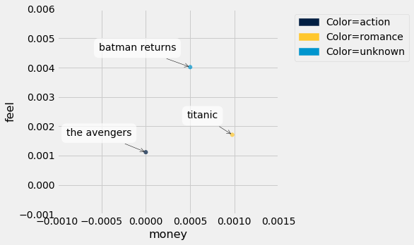

```python
plot_movie_with_two_features("batman returns", train_movies, "money", "feel")
plots.axis([-0.001, 0.0015, -0.001, 0.006])
```

[output not shown]

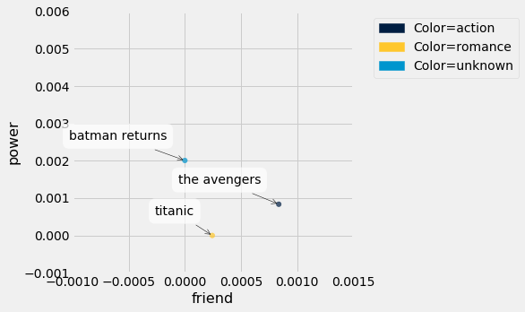

```python
plot_movie_with_two_features("batman returns", training, "friend", "power")
plots.axis([-0.001, 0.0015, -0.001, 0.006])
```

First, write a function to compute the Euclidean distance between two **arrays** of features of *arbitrary* (but equal) length. With our dataset, each item in the array will correspond to the proportion of times a specific word was said.

**Note:** For `n` different features, we compute the difference between corresponding feature values for two movies, square each of the `n` differences, sum up the resulting numbers, and take the square root of the sum.

```python
def distance(features1, features2):
    """Compute the Euclidean distance between two arrays of feature values.
    Each features array should correspond to the values of a specific movie."""
    return (sum((features1 - features2) ** 2) ** (1/2))
```

```python
distance(make_array(0, 0), make_array(3, 4))
### According to the Pythagorean Theorem (a^2 + b^2 = c^2), this line should return 5.
```

```
5.0
```

## Step 3) Choosing the Features

Unfortunately, we usually cannot use all of the features in our classifier. One reason why is *computational* -- computing Euclidean distances takes a long time when we have many (5000!) features.

Therefore, we're going to select a set of words that are very *discriminative*. That is, we hope these features will lead us to correctly classify as much of the test set as possible. This process of choosing features that will make a classifier work well is sometimes called *feature selection*, or more broadly *feature engineering*.

Now, choose your features. Select a set of common words (10-20 is usually enough) that you think might let you distinguish between romance and action movies. Make sure to choose words that are frequent enough that every movie contains at least one of them. A row from the movies table is shown below to help you choose your features.

```python
movies.show(1)
```

| Title | Genre | Year | Rating | # Votes | # Words | i | the | to | a | it | and | that | of | your | what | in | me | is | do | thi | dont | he | for | im | know | have | be | my | we | … |
| --- | --- | --- | --- | --- | --- | --- | --- | --- | --- | --- | --- | --- | --- | --- | --- | --- | --- | --- | --- | --- | --- | --- | --- | --- | --- | --- | --- | --- | --- | --- |
| the terminator | action | 1984 | 8.1 | 183538 | 1849 | 0.0400216 | 0.0438075 | 0.0254191 | 0.0248783 | 0.0346133 | 0.0113575 | 0.0167658 | 0.00865333 | 0.0102758 | 0.00973499 | 0.01298 | 0.01298 | 0.00703083 | 0.00594916 | 0.0102758 | 0.0102758 | 0.00703083 | 0.00865333 | 0.00865333 | 0.00649 | 0.003245 | 0.0102758 | 0.00432666 | 0.00703083 | … |

... (241 rows omitted)

```python
# Set my_features to an array of features (strings that are column labels)

my_features = make_array('i', 'the', 'to', 'a', 'it', 'and', 'that', 'of', 'your', 'what', 'in', 'me', 'is', 'do', 'thi', 'dont', 'he', 'for', 'im', 'know')

## Do not change the code below.
train_features = train_movies.select(my_features)
test_features = test_movies.select(my_features)
```

**FRQ 2:** Please explain your reasoning behind selecting these specific features. In general, what characteristics are you looking for when you choose features for a K-NN classifier?

The words we chose were words we felt would help us distinguish between action and romance movies most easily. We also tried to pick words that are most common and therefore would have the most appearances so we had more data points to work with.

## Step 4) Putting It All Together

Now that we have chosen an algorithm and specific features to look at, we need to apply it to the data. Remember: a K-nearest neighbors classifier takes an unknown data point, checks the classes of the nearby data points, and classifies the unknown point as the majority class out of K neighbors. For example, if an unknown movie is near 3 romance movies and 2 action movies in terms of Euclidean distance, we would classify that movie as romance.

Therefore, we need a few more functions to complete our classifier, which will allow us to do the following steps:

1) Given an unknown movie and a set of known movies with their classes, find the distance between the unknown movie and all of the known movies in the training set.

2) Sort a table with the classes and distances, so that the movies with the closest distances are at the top of the table.

3) Choose the most similar K rows (the ones that are closest in distance) and find the most common class in that group of K.

First, we need to write a function that will find the most common class in a column of a table. It will take in a table and a string containing the name of the column in the table we want to analyze.

For example, if a table (tbl) has a column called "Classes", with the values ["romance", "romance", "action", "action", "action"], we should be able to type most_common("Classes", tbl) and it will output "action".

```python
def most_common(label, table):
    """The most common element in a column of a table.

    This function takes two arguments:
      label: The label of a column, a string.
      table: A table.

    It returns the most common value in that column of that table.
    In case of a tie, it returns any one of the most common values
    """
    new_table = table.group(label)
    new_table = new_table.sort('count', descending = True)
    return new_table.column(0).item(0)
```

```python
### This code should output "romance".
class_example = Table().with_column("Classes", ["romance", "romance", "action"])
most_common("Classes", class_example)
```

```
'romance'
```

Recall that we are using Euclidean distance to determine similarity between movies. When we run our classifier, we will need to calculate the Euclidean distances from an unknown movie (using the selected features) to all movies in the training set. You could do this with a `for` loop and the distances function you wrote previously, but to make it computationally faster, we have provided a function, `fast_distances`, to do this for you. Read its documentation to make sure you understand what it does. (You don't need to read the code in its body unless you want to.)

```python
# Just run this cell to define fast_distances.

def fast_distances(test_row, train_rows):
    """An array of the distances between test_row and each row in train_rows.

    Takes 2 arguments:
      test_row: A row of a table containing features of one
        test movie (e.g., test_features.row(0)).
      train_rows: A table of features (for example, the whole
        table train_features)."""
    assert train_rows.num_columns < 50, "Make sure you're not using all the features of the movies table."
    counts_matrix = np.asmatrix(train_rows.columns).transpose()
    diff = np.tile(np.array(test_row), [counts_matrix.shape[0], 1]) - counts_matrix
    np.random.seed(0) # For tie breaking purposes
    distances = np.squeeze(np.asarray(np.sqrt(np.square(diff).sum(1))))
    eps = np.random.uniform(size=distances.shape)*1e-10 #Noise for tie break
    distances = distances + eps
    return distances
```

Now, we want to be able to classify an unknown movie according to the steps explained above.

Write a function called `classify`. It should take the following four arguments in the same order:

- A row of features for a movie to classify (e.g., `test_features.row(0)`).
- A table with a column for each feature (e.g., `train_features`).
- An array of classes that has as many items as the previous table has rows, and in the same order.
- `k`, the number of neighbors to use in classification.

It should return the class a `k`-nearest neighbor classifier picks for the given row of features (the string `'Romance'` or the string `'Action'`).

```python
def classify(test_row, train_table, train_classes, k):
    """Return the most common class among k nearest neigbors to test_row."""
    genre_and_distances_table = Table().with_columns('Class', train_classes,'Distance', fast_distances(test_row, train_table))
    genre_and_distances = genre_and_distances_table.sort("Distance")
    return most_common('Class', genre_and_distances.take(np.arange(k)))
```

```python
### The following cell should output "action".
king_kong = movies.where("Title", "king kong").select(my_features).row(0)
classify(king_kong, train_features, train_movies.column("Genre"), 1)
```

```
'action'
```

**FRQ 3:** In the cell above, we try to classify a movie from our training set with K = 1. What will the accuracy of our classifier be if we only classified movies from the training set with K = 1? Why?

Now, imagine we used different values of K. What is the issue with using an even value for K? If, for example, we had 75 action movies and 25 romance movies in our training set, what would be the issue with using K = 51? In that situation, what would our accuracy be?

Using your `classify` function, write a new function that takes as its argument a row containing the features of an unknown movie and classifies that row using the k-nearest neighbors algorithm with `train_features` as its training set.

```python
def classify_one_argument(test_row, k):
    return classify(test_row, train_features, train_movies.column('Genre'), k)

# When you're done, this should produce 'Romance' or 'Action'.
classify_one_argument(test_features.row(0), 7)
```

```
'action'
```

### Step 5) Evaluating your classifier

Now that it's easy to use the classifier, let's see how accurate it is on the whole test set.

Use `classify_one_argument` and a for loop to classify every movie in the test set. Choose an appropriate k-value. Name these guesses `test_guesses`. **Then**, compute the proportion of correct classifications.

```python
test_guesses = make_array()
for i in np.arange(test_movies.num_rows):
    guess = classify_one_argument(i,11)
    test_guesses = np.append(test_guesses,guess)

proportion_correct = np.count_nonzero(test_guesses == test_movies.column('Genre')) / test_movies.num_rows
proportion_correct
```

```
0.5675675675675675
```

**FRQ 4:** After creating your first classifier, please write your accuracy as a percentage below. Then, try changing some parts of your classifier (the features, K, etc.) by adjusting previous coding cells to try to increase the accuracy. What is the new accuracy? What did you change? Why did this affect your classifier?

At this point, you've gone through one cycle of classifier design. Let's summarize the steps:

1. From available data, select test and training sets.
2. Choose an algorithm you're going to use for classification.
3. Identify some features.
4. Define a classifier function using your features and the training set.
5. Evaluate its performance (the proportion of correct classifications) using the test set.

Keep in mind that this is a very basic form of supervised machine learning. If you continue in data science and take courses such as Computer Science 289: Intro to Machine Learning or Data Science 200: Principles and Techniques of Data Science, you will learn ways to improve this classifier and other ML techniques.

# Part 2. Using Real World Data

The majority of assignments in this class have dealt with handpicked data that do not represent the real world at all! Most of the time, our data is not clean. Here, we are going to expose you to real world data.

This data comes from North Fair Oaks, a census-designated place in San Mateo County. The area is also referred to as "Little Michoacán" due to the large amount of residents of Mexican descent.

The dataset in question is a record of Violations to the Enforcment Code of North Fair Oaks. [Taken from their website:](https://planning.smcgov.org/documents/north-fair-oaks-code-enforcement-guide)

```
North Fair Oaks Code Enforcement Guide
It is an effort being coordinated by the County of San Mateo to improve the condition of property in the North Fair Oaks area. If you live or do business in North Fair Oaks, you probably share the County's concern about the accumulation of abandoned vehicles, junk, trash and weeds on some properties in the community.
```

We have cleaned the majority of the dataset for you. The original dataset contained a description of the violation, where we have transformed it into proportions of the top 25 words accross all descriptions. We also have a class and latitude and longitude points for each complaint. If you are interested in how to do, the process is called Natural Language Processing, and in Python, the main tool is NLTK - Natural Language Toolkit. You can find more information [here.](https://www.nltk.org/)

Each row represents a violation tied to a single property. For example, if a house has junk, weeds, grafitti, or various other forms of disrepair, it is labeled as `Disrepair`. If there are additional people living on the property, or an illegal addition to a house has been made it is labeled, `Addition`.

```python
violations_original = Table.read_table("violations.csv")
violations_original.show(5)
```

| Unnamed: 0 | graffiti | illegal | dumping | property | private | "sc" | side | addition | must | fence | garage | building | overgrown | utility | permit | wall | front | living | rear | structure | property, | removed | ave. | corner | DESCRIPTION | ADDRESS | lat | long | ID | … |
| --- | --- | --- | --- | --- | --- | --- | --- | --- | --- | --- | --- | --- | --- | --- | --- | --- | --- | --- | --- | --- | --- | --- | --- | --- | --- | --- | --- | --- | --- | --- |
| 0 | 0 | 0.125 | 0 | 0 | 0 | 0 | 0 | 0 | 0 | 0 | 0 | 0 | 0 | 0 | 0 | 0 | 0 | 0 | 0 | 0.125 | 0 | 0 | 0 | 0 | code violations and illegal addition/remodel/modificatio ... | 861 HURLINGAME AVE, REDWOOD CITY, CA | 37.4834 | -122.207 | VIO2015-00420 | … |
| 1 | 0 | 0.0307692 | 0 | 0.0153846 | 0 | 0 | 0 | 0.0461538 | 0.0307692 | 0 | 0.0307692 | 0 | 0 | 0 | 0.0307692 | 0 | 0 | 0 | 0.0307692 | 0 | 0 | 0 | 0 | 0 | "sc" SFD with illegal studio addition attached to rear o ... | 2933 CURTIS AVE, REDWOOD CITY, CA 94063 | 37.4737 | -122.209 | VIO2015-00400 | … |
| 2 | 0.03125 | 0.0625 | 0 | 0 | 0 | 0 | 0 | 0.03125 | 0.03125 | 0.03125 | 0 | 0 | 0 | 0 | 0 | 0 | 0 | 0 | 0 | 0.03125 | 0 | 0.03125 | 0 | 0 | "sc" 4 illegal detached accessory structures that must b ... | 339 1ST AVE, REDWOOD CITY, CA | 37.4736 | -122.208 | VIO2014-00316 | … |
| 3 | 0 | 0 | 0 | 0 | 0 | 0 | 0 | 0 | 0 | 0 | 0 | 0 | 0 | 0 | 0 | 0 | 0 | 0 | 0 | 0 | 0 | 0 | 0 | 0 | Patio between main house and 2nd unit was filled in and ... | 2832 HUNTINGTON AVE, REDWOOD CITY, CA 94062-0000 | 37.4748 | -122.21 | VIO2017-00345 | … |
| 4 | 0 | 0.15 | 0 | 0 | 0 | 0 | 0 | 0.05 | 0 | 0 | 0 | 0 | 0 | 0 | 0 | 0 | 0 | 0 | 0 | 0 | 0 | 0 | 0 | 0 | "sc" Illegal roosters and chickens, illegal structures, ... | 425 DUMBARTON AVE, REDWOOD CITY, CA | 37.4757 | -122.209 | VIO2015-00067 | … |

... (413 rows omitted)

# Step 1) Cleaning the Data

For the most part, our dataset is clean. However, there are a few things we need to remove before we can continue our analysis.

First, the `Unnamed: 0` column is unnecessary; it only exists to label the index of each row. Second, we want to focus on the SF Bay Area (particularly North Fair Oaks) and the dataset includes a few extra data points outside of that region.

Clean the dataset, called `violations_original`, by removing the first column and removing any rows that do NOT have a latitude between 37.4 and 37.5 and a longitude between -122.3 and -122. Call the new table `violations`.

```python
violations = violations_original.drop("Unnamed: 0").where("lat",are.between(37.4,37.5)).where("long",are.between(-122.3,-122))
violations.show(5)
```

| graffiti | illegal | dumping | property | private | "sc" | side | addition | must | fence | garage | building | overgrown | utility | permit | wall | front | living | rear | structure | property, | removed | ave. | corner | DESCRIPTION | ADDRESS | lat | long | ID | CLASS |
| --- | --- | --- | --- | --- | --- | --- | --- | --- | --- | --- | --- | --- | --- | --- | --- | --- | --- | --- | --- | --- | --- | --- | --- | --- | --- | --- | --- | --- | --- |
| 0 | 0.125 | 0 | 0 | 0 | 0 | 0 | 0 | 0 | 0 | 0 | 0 | 0 | 0 | 0 | 0 | 0 | 0 | 0 | 0.125 | 0 | 0 | 0 | 0 | code violations and illegal addition/remodel/modificatio ... | 861 HURLINGAME AVE, REDWOOD CITY, CA | 37.4834 | -122.207 | VIO2015-00420 | Addition |
| 0 | 0.0307692 | 0 | 0.0153846 | 0 | 0 | 0 | 0.0461538 | 0.0307692 | 0 | 0.0307692 | 0 | 0 | 0 | 0.0307692 | 0 | 0 | 0 | 0.0307692 | 0 | 0 | 0 | 0 | 0 | "sc" SFD with illegal studio addition attached to rear o ... | 2933 CURTIS AVE, REDWOOD CITY, CA 94063 | 37.4737 | -122.209 | VIO2015-00400 | Addition |
| 0.03125 | 0.0625 | 0 | 0 | 0 | 0 | 0 | 0.03125 | 0.03125 | 0.03125 | 0 | 0 | 0 | 0 | 0 | 0 | 0 | 0 | 0 | 0.03125 | 0 | 0.03125 | 0 | 0 | "sc" 4 illegal detached accessory structures that must b ... | 339 1ST AVE, REDWOOD CITY, CA | 37.4736 | -122.208 | VIO2014-00316 | Addition |
| 0 | 0 | 0 | 0 | 0 | 0 | 0 | 0 | 0 | 0 | 0 | 0 | 0 | 0 | 0 | 0 | 0 | 0 | 0 | 0 | 0 | 0 | 0 | 0 | Patio between main house and 2nd unit was filled in and ... | 2832 HUNTINGTON AVE, REDWOOD CITY, CA 94062-0000 | 37.4748 | -122.21 | VIO2017-00345 | Addition |
| 0 | 0.15 | 0 | 0 | 0 | 0 | 0 | 0.05 | 0 | 0 | 0 | 0 | 0 | 0 | 0 | 0 | 0 | 0 | 0 | 0 | 0 | 0 | 0 | 0 | "sc" Illegal roosters and chickens, illegal structures, ... | 425 DUMBARTON AVE, REDWOOD CITY, CA | 37.4757 | -122.209 | VIO2015-00067 | Addition |

... (394 rows omitted)

# Step 2) Splitting the Dataset

Let's split the training and test sets, using the same process we used to split the movies dataset.

```python
training_proportion = 17/20

### Do not change the code below.
violations_permuted = violations.sample(with_replacement = False)
num_violations = violations.num_rows
num_train = int(training_proportion * num_violations)
train_violations = violations_permuted.take(np.arange(num_train))
num_test = num_violations - num_train
num_addition = train_violations.where("CLASS", "Addition").num_rows
num_disrepair = train_violations.where("CLASS", "Disrepair").num_rows
test_violations = violations_permuted.take(np.arange(num_train, num_violations))
print("The number of reports in the training set is " + str(num_train) + ".",
      "The number of reports in the test set is " + str(num_test) + ".")
print("In the training set, there are " + str(num_addition) + " addition reports.",
     "There are " + str(num_disrepair) + " disrepair reports.")
```

```
The number of reports in the training set is 339. The number of reports in the test set is 60.
In the training set, there are 61 addition reports. There are 278 disrepair reports.
```

# Step 3) Judging Quality of the Data

```python
### Do not change the following cell.
def plot_with_two_features(training_records, x_feature, y_feature):

    plots = Table().with_columns(
        x_feature, [training_records.row(0).item(x_feature)],
        y_feature, [training_records.row(0).item(y_feature)],
        "Color", ["unknown"],
    )

    for i in np.arange(training_records.num_rows):
        row = training_records.row(i)
        plots.append([row.item(x_feature), row.item(y_feature), row.item("CLASS")])

    plots.scatter(x_feature, y_feature, colors="Color", s=30)

training_examples = train_violations.take(np.arange(50))
```

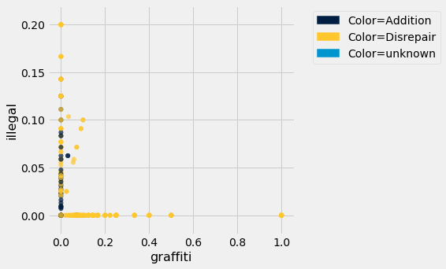

```python
plot_with_two_features(train_violations, "graffiti", "illegal")
```

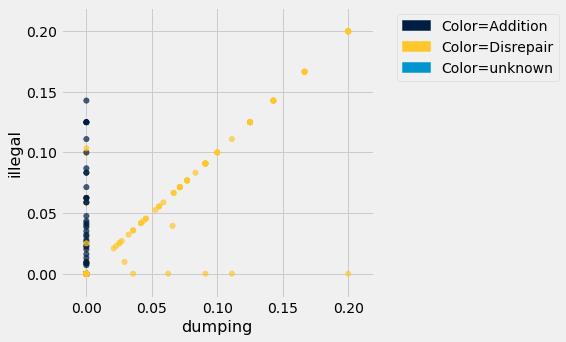

```python
plot_with_two_features(train_violations, "dumping", "illegal")
```

**FRQ 5:** Comment on the plots above. What do you notice? How is this different from the movies dataset? Judging from these specific words (and any additional graphs you generate, if you are interested in exploring more), would these features be better or worse for classification than the movie features? Why or why not?

# 3) Mapping It!

In the following section, we will practice mapping geographic data. Remember the maps function built into datascience - you can find more information in the datascience documentation [here.](http://data8.org/datascience/maps.html)

The next cell creates the tables and functions necessary for maps. In this case, we want to color Additions `black` and Disrepairs `yellow`.

```python
### Do not change the code in this cell.
graphed_violations = violations.sample(50)
def color_func(x):
    if x == "Addition":
        return 'black'
    else:
        return 'yellow'

color_array = make_array()
for i in graphed_violations.column("CLASS"):
    val = color_func(i)
    color_array = np.append(color_array, val)

map_table = Table().with_columns(
    "lat", graphed_violations.column("lat"),
    "long", graphed_violations.column("long"),
    "label", graphed_violations.column("CLASS"),
    "color", color_array
    )
map_table
```

| lat | long | label | color |
| --- | --- | --- | --- |
| 37.4787 | -122.207 | Disrepair | yellow |
| 37.4784 | -122.201 | Addition | black |
| 37.4725 | -122.205 | Disrepair | yellow |
| 37.47 | -122.207 | Disrepair | yellow |
| 37.4734 | -122.214 | Addition | black |
| 37.4734 | -122.215 | Disrepair | yellow |
| 37.4744 | -122.211 | Disrepair | yellow |
| 37.4744 | -122.209 | Disrepair | yellow |
| 37.4689 | -122.208 | Disrepair | yellow |
| 37.4741 | -122.208 | Disrepair | yellow |

... (40 rows omitted)

Plot the 50 different reports, called `map_table` below, by using the maps function. For formatting reasons, the only argument you will need to input is map_table, since the table columns are already in the correct order. A large red box may appear when you generate the map; this should not be an issue.

```python
Circle.map_table(map_table)
```

[interactive chart not shown]

**FRQ 6:** What do you notice about the map above? What are some potential causes for your observations?

In general, do you think would geographic data be useful as features in a classifier? If so, how would you use that data to create said classifier?

What we have noticed is that most of the plot points for addition are clustered around Middlefield road and along the Caltrain line. There is a sudden cluster starting at Semicircular Road and Middlefield. Some potential causes for this could be that this may be a low income neighbourhood which is why people might be rooming with others more than other neighbourhoods to afford rent. It would be useful because the addition points being right along the Caltrain tracks shows a pattern. The more data points there are the clearer it would be if this pattern was strong or not and therefore Geographic Data can be quite useful.

# 4) Writing the Classifier

Now, let's use the bag-of-words classifier again. We will ignore the latitude and longitude data, since it will require some extra coding that is out of the scope of this course. If you are interested in using geographic data for classification, we recommend looking into GIS (Geographic Information System). That being said, remember the process with movies and songs:

1) Given an unknown data point and a set with known classes (the training set), find the distance between the unknown point and all of the known points in the training set.

2) Attach the distances to a table with the classes, and sort the table so that the points with the smallest distances are at the top of the table.

3) Choose the most similar K rows (the ones that are closest in distance) and find the most common class in that group of K.

To do so, we will first need to choose our features. Assign the `features` to a list or array of features (words) you want to use in your classification. One row of the violations table, containing the features, is shown below for your reference.

```python
violations.show(1)
```

| graffiti | illegal | dumping | property | private | "sc" | side | addition | must | fence | garage | building | overgrown | utility | permit | wall | front | living | rear | structure | property, | removed | ave. | corner | DESCRIPTION | ADDRESS | lat | long | ID | CLASS |
| --- | --- | --- | --- | --- | --- | --- | --- | --- | --- | --- | --- | --- | --- | --- | --- | --- | --- | --- | --- | --- | --- | --- | --- | --- | --- | --- | --- | --- | --- |
| 0 | 0.125 | 0 | 0 | 0 | 0 | 0 | 0 | 0 | 0 | 0 | 0 | 0 | 0 | 0 | 0 | 0 | 0 | 0 | 0.125 | 0 | 0 | 0 | 0 | code violations and illegal addition/remodel/modificatio ... | 861 HURLINGAME AVE, REDWOOD CITY, CA | 37.4834 | -122.207 | VIO2015-00420 | Addition |

... (398 rows omitted)

```python
features = make_array('graffiti','illegal','dumping','property','private','"sc"','side','addition','must','fence','garage','building','overgrown','utility','permit','wall','front','living','rear','structure','property','removed','ave.','corner')
```

Now that you have your features selected, write a function called `classify_violation` that will classify a report for you. Feel free to use any functions we have used or written earlier in this project. If you are struggling, try reviewing the movies or songs classifiers.

It should take 2 inputs: `row` being a specific report you would like to classify and `k` being the number of nearest neighbors you would like to use in your classification.

```python
def classify_violation(row, k):
     return classify(row,train_violations.select(features),train_violations.column("CLASS"),k)
```

Now, classify 2 training violations with a K value of 1 to test if our classifier works. The report with the ID `VIO2016-00285` should output `Addition`, while the report with the ID of `VIO2017-00430` should output `Disrepair`.

```python
VIO2016_00285=violations.where("ID",are.equal_to("VIO2016-00285")).select(features)
classify_violation(VIO2016_00285.row(0),1)
```

```
'Addition'
```

```python
VIO2017_00430=violations.where("ID",are.equal_to("VIO2017-00430")).select(features)
VIO2017_00430
classify_violation(VIO2017_00430.row(0),1)
```

```
'Disrepair'
```

Now that we know that our function works, let's try to calculate the accuracy of the classifier. Use your classifier on the test set and find the accuracy.

```python
test_guesses2 = make_array()
for i in np.arange(test_violations.num_rows):
    guess2=classify_violation(test_violations.select(features).row(i),7)
    test_guesses2=np.append(test_guesses2,guess2)
classifier_accuracy = np.count_nonzero(test_guesses2==test_violations.column("CLASS"))/test_violations.num_rows
classifier_accuracy
```

```
0.9833333333333333
```

**FRQ 7:** Depending on your features chosen, you may notice that the prediction accuracy is very high (>90%. If you are not getting this, try using different features). Why is this the case?

What factors did you take into account when building your classifier? Knowing the number of `Disrepair` and `Addition` reports in the training set, what is the minimum value of K that would always result in every prediction being "Disrepair" or "Addition" only?

Lastly, do you see any issues with using this classifier or dataset? If you could continue exploring this data, what would you like to research?

Congratulations! You wrote multiple K-nearest neighbors classifiers, classifying unknown songs, movies, and violation reports. If you're interested in learning more about classification, we recommend reading the [Data 200 textbook](https://www.textbook.ds100.org/ch/17/classification_intro.html). For example, you may ask: how do we choose the best K value? We can use cross-validation, explained here: https://www.textbook.ds100.org/ch/15/bias_cv.html.

Please submit this notebook to bCourses by saving it as both a .html and a .ipynb. Make sure you and your partners' names are listed on this notebook and/or bCourses.